# assignment 2_ariana marastuti

Tamas Nagy

2022-05-03

You will have to create 3 plots based on the datasets and instructions detailed below. You will find the plots themeselves in the `assignments/assignment_2_plots`. Your task is to write the code that will reproduce the plots as closely as possible.

# Skills needed to solve this assignment

- Using R and RStudio, reading data
- Reporting using RMarkdown
- Using Git and Github (for submitting the task)
- Data manipulation (e.g. dplyr, tidyr), and working with factors (forcats)
- Data visuzlization (ggplot2)

## Task 1: Climbing expeditions

The 2020-09-22 TidyTueday datasets are about climbing expeditions. From the three datasets, use the “expeditions”. Reproduce the plot below! Notice a few things:

- Use `forcats::fct_lump()` to get the 15 most frequent peaks, and drop the “Other” category.
- The bars are ordered by the sum of all expeditions (use `fct_reorder()`).
- The bar colors use the viridis palette and light theme.

```
## spec_tbl_df [10,364 × 16] (S3: spec_tbl_df/tbl_df/tbl/data.frame)
##  $ expedition_id     : chr [1:10364] "ANN260101" "ANN269301" "ANN273101" "ANN278301" ...
##  $ peak_id           : chr [1:10364] "ANN2" "ANN2" "ANN2" "ANN2" ...
##  $ peak_name         : chr [1:10364] "Annapurna II" "Annapurna II" "Annapurna II" "Annapurna II" ...
##  $ year              : num [1:10364] 1960 1969 1973 1978 1979 ...
##  $ season            : chr [1:10364] "Spring" "Autumn" "Spring" "Autumn" ...
##  $ basecamp_date     : Date[1:10364], format: "1960-03-15" "1969-09-25" ...
##  $ highpoint_date    : Date[1:10364], format: "1960-05-17" "1969-10-22" ...
##  $ termination_date  : Date[1:10364], format: NA "1969-10-26" ...
##  $ termination_reason: chr [1:10364] "Success (main peak)" "Success (main peak)" "Success (main peak)" "Bad weather (storms, high winds)" ...
##  $ highpoint_metres  : num [1:10364] 7937 7937 7937 7000 7160 ...
##  $ members           : num [1:10364] 10 10 6 2 3 6 7 19 9 5 ...
##  $ member_deaths     : num [1:10364] 0 0 0 0 0 1 0 0 1 0 ...
##  $ hired_staff       : num [1:10364] 9 0 8 0 0 2 2 0 3 0 ...
##  $ hired_staff_deaths: num [1:10364] 0 0 0 0 0 0 0 0 0 0 ...
##  $ oxygen_used       : logi [1:10364] TRUE FALSE FALSE FALSE FALSE FALSE ...
##  $ trekking_agency   : chr [1:10364] NA NA NA NA ...
##  - attr(*, "spec")=
##   .. cols(
##   ..   expedition_id = col_character(),
##   ..   peak_id = col_character(),
##   ..   peak_name = col_character(),
##   ..   year = col_double(),
##   ..   season = col_character(),
##   ..   basecamp_date = col_date(format = ""),
##   ..   highpoint_date = col_date(format = ""),
##   ..   termination_date = col_date(format = ""),
##   ..   termination_reason = col_character(),
##   ..   highpoint_metres = col_double(),
##   ..   members = col_double(),
##   ..   member_deaths = col_double(),
##   ..   hired_staff = col_double(),
##   ..   hired_staff_deaths = col_double(),
##   ..   oxygen_used = col_logical(),
##   ..   trekking_agency = col_character()
##   .. )
##  - attr(*, "problems")=<externalptr>
```

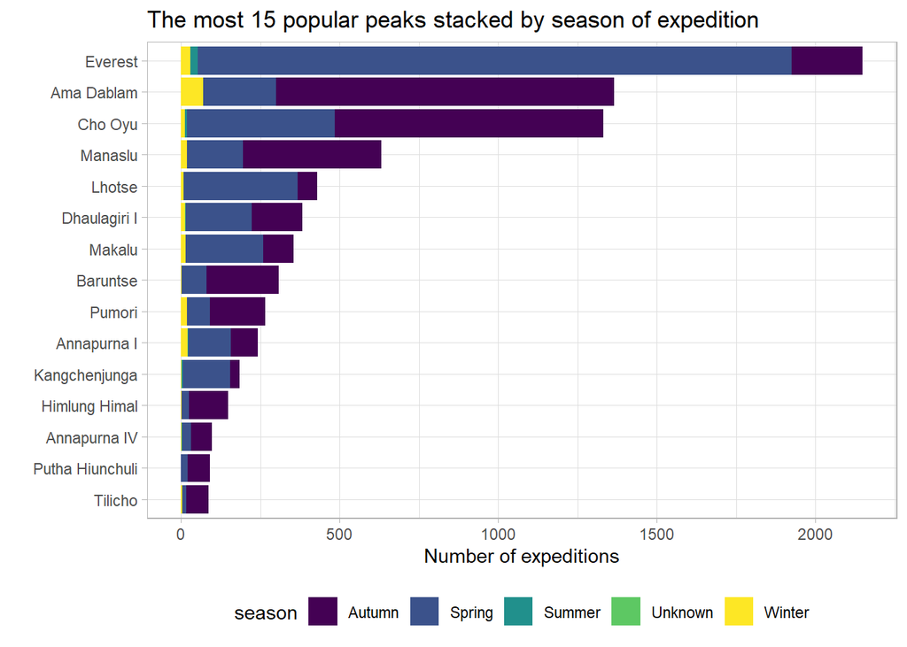

```
## spec_tbl_df [3,370 × 5] (S3: spec_tbl_df/tbl_df/tbl/data.frame)
##  $ broad_field: chr [1:3370] "Life sciences" "Life sciences" "Life sciences" "Life sciences" ...
##  $ major_field: chr [1:3370] "Agricultural sciences and natural resources" "Agricultural sciences and natural resources" "Agricultural sciences and natural resources" "Agricultural sciences and natural resources" ...
##  $ field      : chr [1:3370] "Agricultural economics" "Agricultural and horticultural plant breeding" "Agricultural animal breeding" "Agronomy and crop science" ...
##  $ year       : num [1:3370] 2008 2008 2008 2008 2008 ...
##  $ n_phds     : num [1:3370] 111 28 3 68 41 18 77 182 52 96 ...
##  - attr(*, "spec")=
##   .. cols(
##   ..   broad_field = col_character(),
##   ..   major_field = col_character(),
##   ..   field = col_character(),
##   ..   year = col_double(),
##   ..   n_phds = col_double()
##   .. )
##  - attr(*, "problems")=<externalptr>
```

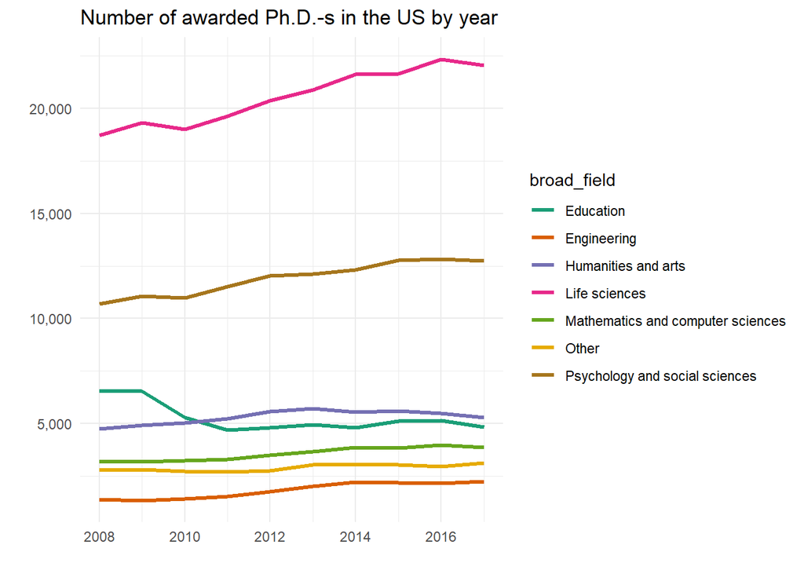

## Task 3: Commute in the US

The 2019-11-05 TidyTueday dataset is about commuting to work in each city in the US by bike or on foot. There is only one dataset, it is called `commute`. Reproduce the plot below!

```
## # A tibble: 6 × 9
##   city          state city_size mode      n percent   moe state_abb state_region
##   <chr>         <chr> <chr>     <chr> <dbl>   <dbl> <dbl> <chr>     <chr>
## 1 Aberdeen city Sout… Small     Bike    110     0.8   0.5 SD        North Centr…
## 2 Acworth city  Geor… Small     Bike      0     0     0.4 GA        South
## 3 Addison vill… Illi… Small     Bike     43     0.2   0.3 IL        North Centr…
## 4 Adelanto city Cali… Small     Bike      0     0     0.5 CA        West
## 5 Adrian city   Mich… Small     Bike    121     1.5   1   MI        North Centr…
## 6 Agawam Town … Mass… Small     Bike      0     0     0.2 MA        Northeast
```

```
## spec_tbl_df [3,496 × 9] (S3: spec_tbl_df/tbl_df/tbl/data.frame)
##  $ city        : chr [1:3496] "Aberdeen city" "Acworth city" "Addison village" "Adelanto city" ...
##  $ state       : chr [1:3496] "South Dakota" "Georgia" "Illinois" "California" ...
##  $ city_size   : chr [1:3496] "Small" "Small" "Small" "Small" ...
##  $ mode        : chr [1:3496] "Bike" "Bike" "Bike" "Bike" ...
##  $ n           : num [1:3496] 110 0 43 0 121 0 84 23 0 576 ...
##  $ percent     : num [1:3496] 0.8 0 0.2 0 1.5 0 0.8 0.2 0 1.5 ...
##  $ moe         : num [1:3496] 0.5 0.4 0.3 0.5 1 0.2 1.1 0.3 0.2 0.4 ...
##  $ state_abb   : chr [1:3496] "SD" "GA" "IL" "CA" ...
##  $ state_region: chr [1:3496] "North Central" "South" "North Central" "West" ...
##  - attr(*, "spec")=
##   .. cols(
##   ..   city = col_character(),
##   ..   state = col_character(),
##   ..   city_size = col_character(),
##   ..   mode = col_character(),
##   ..   n = col_double(),
##   ..   percent = col_double(),
##   ..   moe = col_double(),
##   ..   state_abb = col_character(),
##   ..   state_region = col_character()
##   .. )
##  - attr(*, "problems")=<externalptr>
```

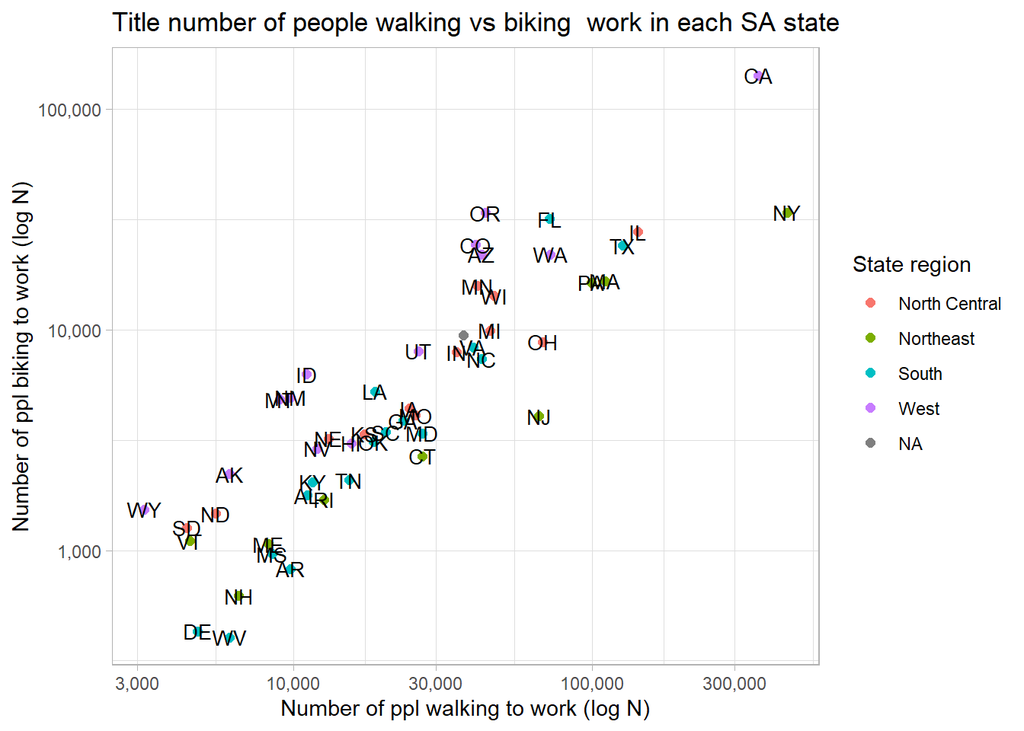